# Gaze Following confirmatory Analysis

The Gaze Following Analysis Team

Sat Mar 16 20:47:12 2019

# 1 Intro

This RMarkdown file reports analyses of the primary Gaze Following dataset. It relies on data cached in `03_exclusions.Rmd`.

There are four datasets for MLM models

- d_first: direction of first look (congruent/incongruent) and latency of first shifts. Proportion difference score (c-i)/(c+i)
- d_freq: frequency of looks to congruent vs. incongruent. Proportion difference score (c-i)/(c+i)
- d_duration: fixation duration to congruent vs. incongruent. Proportion difference score (c-i)/(c+i)
- d_latency: infants’ reaction time

And their associated datasets for meta-analysis

- d_first_meta: direction of first look (congruent/incongruent) and latency of first shifts. Proportion difference score (c-i)/(c+i)
- d_freq_meta: frequency of looks to congruent vs. incongruent. Proportion difference score (c-i)/(c+i)
- d_duration_meta: fixation duration to congruent vs. incongruent. Proportion difference score (c-i)/(c+i)
- d_latency_meta: infants’ reaction time

```r
iv_columns <- c("lab", "subid", "trial_num", "age_group", "age_days", "participant_gender", "lang_group", "coding")
dv_columns <- c("first_shift", "latency", "n_shift_congruent", "n_shift_incongruent", "fixation_congruent", "fixation_incongruent")

d <- read_csv("processed_data/03_data_trial_main.csv") %>%
  select(iv_columns, dv_columns) %>%
  mutate_at(vars(lab,subid,age_group, participant_gender, lang_group, first_shift, coding), as.factor) %>%
  mutate_at(vars(age_group, lang_group), fct_rev)
```

Create datasets for analysis. Meta-analytic sets have mean by infant

```r
d_first <- d %>%
  filter(!is.na(first_shift)) %>% # Select only trials that had a shift
  select(-latency, -n_shift_congruent, -n_shift_incongruent, -fixation_congruent, - fixation_incongruent)

d_first_meta <- d_first %>%
  group_by_at(vars(-trial_num)) %>%
  summarise(n = n()) %>%
  spread(key = first_shift, value = n, fill = 0) %>%
  mutate(prop = (congruent-incongruent)/(congruent+incongruent)) %>% # Calculate proportion difference score
  select(-congruent, -incongruent) %>%
  filter(!is.na(prop)) %>%
  group_by(subid, age_group, lang_group, lab) %>%
  summarise(prop = mean(prop, na.rm = TRUE))

d_freq <- d %>%
  select(-first_shift, -latency, -fixation_congruent, - fixation_incongruent) %>%
  filter((n_shift_congruent + n_shift_incongruent) > 0) %>% # Select only trials that had a shift
  gather(key = "object", value = "n_shift", n_shift_congruent, n_shift_incongruent) %>%
  mutate(object = case_when(
    object == "n_shift_congruent" ~ "congruent",
    object == "n_shift_incongruent" ~ "incongruent"
  )) %>%
  mutate(object = as.factor(object))

d_freq_meta <- d  %>%
  group_by_at(vars(-trial_num)) %>%
  select(-first_shift, -latency, -fixation_congruent, - fixation_incongruent) %>%
  filter((n_shift_congruent + n_shift_incongruent) > 0) %>% # Select only trials that had a shift
  mutate(prop = (n_shift_congruent -  n_shift_incongruent)/(n_shift_congruent + n_shift_incongruent)) %>% # Calculate proportion difference score on each trial
  group_by_at(vars(-trial_num, - prop)) %>%
  mutate(prop = mean(prop)) %>% # Average proportion difference score by baby
  group_by(subid, age_group, lang_group, lab) %>%
  summarise(prop = mean(prop, na.rm = TRUE))

d_duration <- d %>%
  select(-first_shift, -latency, -n_shift_congruent, -n_shift_incongruent) %>%
  filter(fixation_congruent + fixation_incongruent > 0) %>% # Select only trials that had any looking
  gather(key = "object", value = "duration", fixation_congruent, fixation_incongruent) %>%
  mutate(object = case_when(
    object == "fixation_congruent" ~ "congruent",
    object == "fixation_incongruent" ~ "incongruent"
  )) %>%
  mutate(object = as.factor(object)) %>%
  mutate(duration = log(duration + 1)) # Log-transform duration scores, adding one to deal with zeros


d_duration_meta <- d %>%
  select(-first_shift, -latency, -n_shift_congruent, -n_shift_incongruent) %>%
  filter(fixation_congruent + fixation_incongruent > 0) %>%
  mutate(prop = (fixation_congruent - fixation_incongruent)/(fixation_congruent + fixation_incongruent)) %>% # Calculate proportion difference score
  group_by_at(vars(-trial_num, - prop)) %>%
  mutate(prop = mean(prop)) # Average proportion difference score by baby


d_latency <- d %>%
  select(-n_shift_congruent, -n_shift_incongruent, -fixation_congruent, - fixation_incongruent) %>%
  rename("object" = "first_shift") %>%
  filter(!is.na(object)) %>% # only trials with first shifts
  mutate(latency = log(latency + 1)) # Log transform latency scores, adding one to deal with zeros


d_latency_meta <- d %>%
  select(-n_shift_congruent, -n_shift_incongruent, -fixation_congruent, - fixation_incongruent) %>%
  rename("object" = "first_shift") %>%
  filter(!is.na(object)) %>%
  mutate(object = as.factor(object)) %>%
  group_by_at(vars(-trial_num, - latency)) %>%
  mutate(latency = mean(latency)) # Average proportion difference score by baby
```

# 2 Dataset Descriptives

Plot of participants across age.

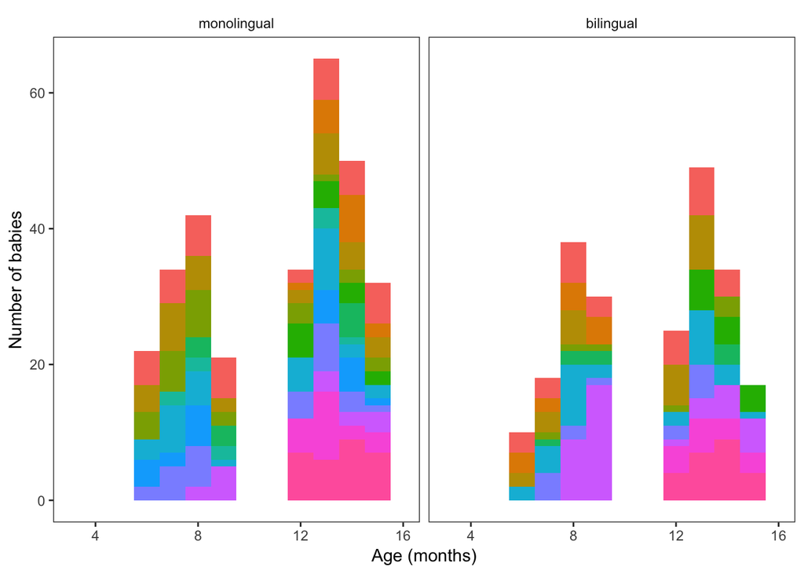

```r
participants <- d %>%
  group_by(lab, subid, lang_group) %>%
  summarise(age_days = age_days[1])

ggplot(participants,
       aes(x = age_days/(365.25/12), fill = lab)) +
  geom_histogram(binwidth = 1) +
  facet_grid(.~lang_group) +
  ylab("Number of babies") +
  xlab("Age (months)") +
  xlim(3, 16) +
  scale_fill_discrete(guide = FALSE)
```

Number of included babies from each lab.

```r
d %>%
  group_by(lab, age_group, lang_group) %>%
  summarize(n = n_distinct(subid)) %>%
  spread(key = lang_group, value = n) %>%
  mutate(monolingual = replace_na(monolingual, 0),
         bilingual = replace_na(bilingual, 0)) %>%
  kable()
```

| lab | age_group | monolingual | bilingual |
| --- | --- | --- | --- |
| babylab-brookes | 6-9 mo | 22 | 15 |
| babylab-brookes | 12-15 mo | 19 | 16 |
| babylab-princeton | 6-9 mo | 0 | 13 |
| babylab-princeton | 12-15 mo | 15 | 0 |
| babylab-westernsydney | 6-9 mo | 18 | 10 |
| babylab-westernsydney | 12-15 mo | 15 | 14 |
| bll-umanitoba | 6-9 mo | 19 | 3 |
| bll-umanitoba | 12-15 mo | 8 | 4 |
| cdc-ceu | 12-15 mo | 14 | 14 |
| elp-georgetown | 6-9 mo | 6 | 5 |
| elp-georgetown | 12-15 mo | 5 | 3 |
| infantlanglab-utk | 6-9 mo | 6 | 0 |
| infantlanglab-utk | 12-15 mo | 4 | 0 |
| irl-concordia | 6-9 mo | 16 | 17 |
| irl-concordia | 12-15 mo | 18 | 14 |
| koku-hamburg | 6-9 mo | 12 | 0 |
| koku-hamburg | 12-15 mo | 11 | 0 |
| lll-liv | 6-9 mo | 13 | 7 |
| lll-liv | 12-15 mo | 15 | 7 |
| nusinfantlanguagecentre | 6-9 mo | 7 | 26 |
| nusinfantlanguagecentre | 12-15 mo | 8 | 14 |
| upf_barcelona | 12-15 mo | 20 | 15 |
| weltentdecker-zurich | 12-15 mo | 29 | 24 |

Total babies: 521.

On how many trials do infants make a face-to-object saccade?

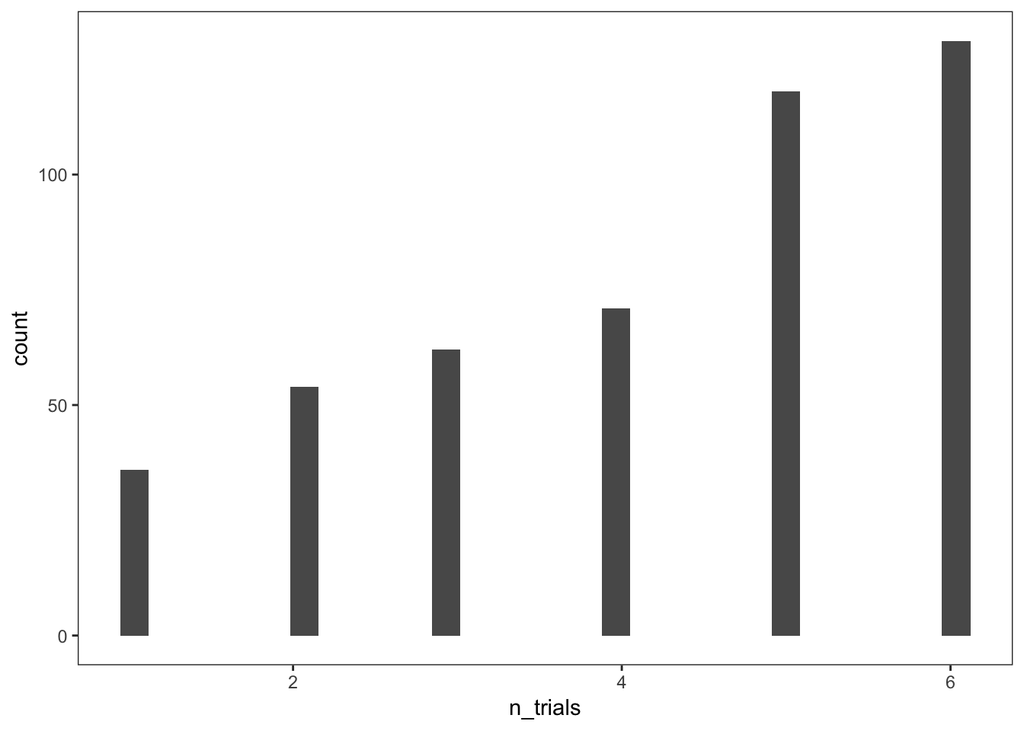

```r
d_latency %>%
  group_by(subid, age_group) %>%
  filter(!is.na(latency)) %>%
  summarize(n_trials = length(trial_num)) %>%
  ggplot(aes(x = n_trials)) +
  geom_histogram()
```

On how many trials do infants look at the target object?

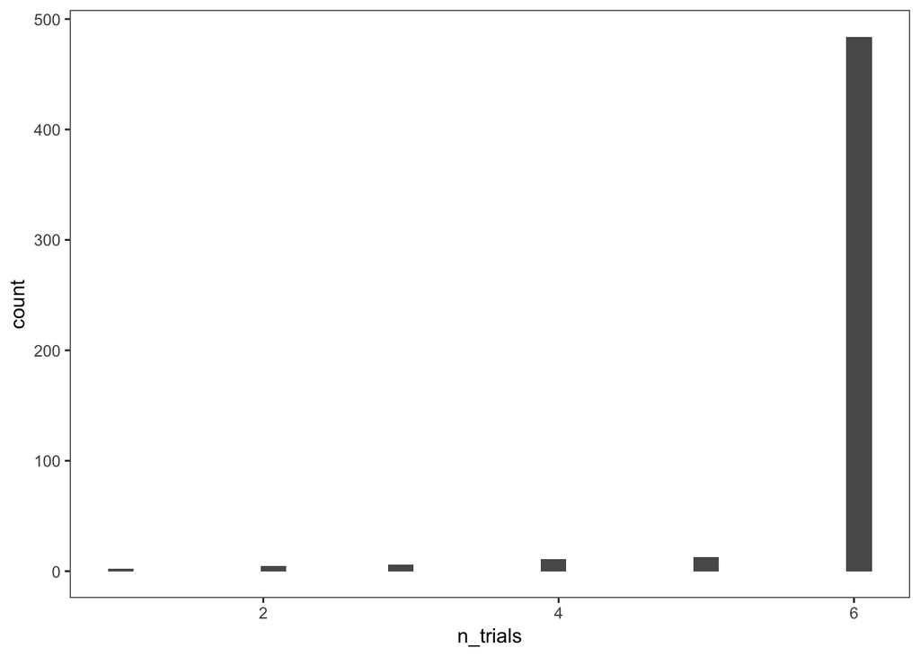

```r
d %>%
  group_by(subid, age_group) %>%
  filter(!is.na(fixation_congruent)) %>%
  summarize(n_trials = length(trial_num)) %>%
  ggplot(aes(x = n_trials)) +
  geom_histogram()
```

What is the distribution of infants’ first-look proportions?

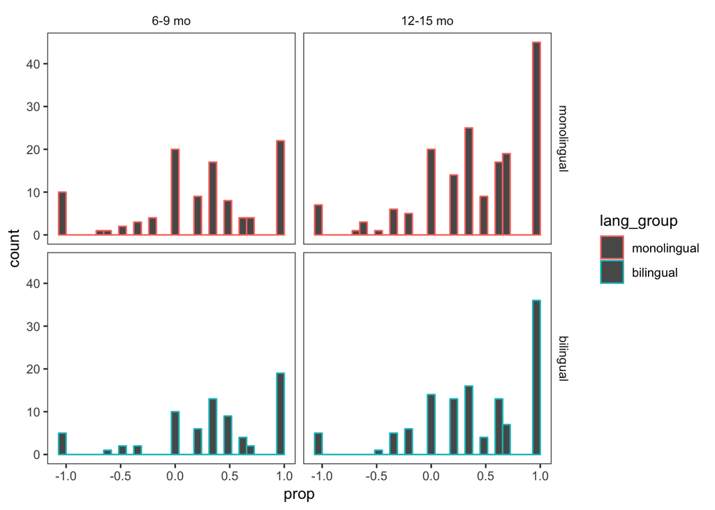

```r
d_first_meta %>%
  group_by(subid, age_group, lang_group) %>%
  summarise(prop = mean(prop, na.rm = TRUE)) %>%
  ggplot(aes(x = prop, color = lang_group)) +
  facet_grid(lang_group~age_group) +
  geom_histogram()
```

# 3 Pirate plots

## 3.1 First look

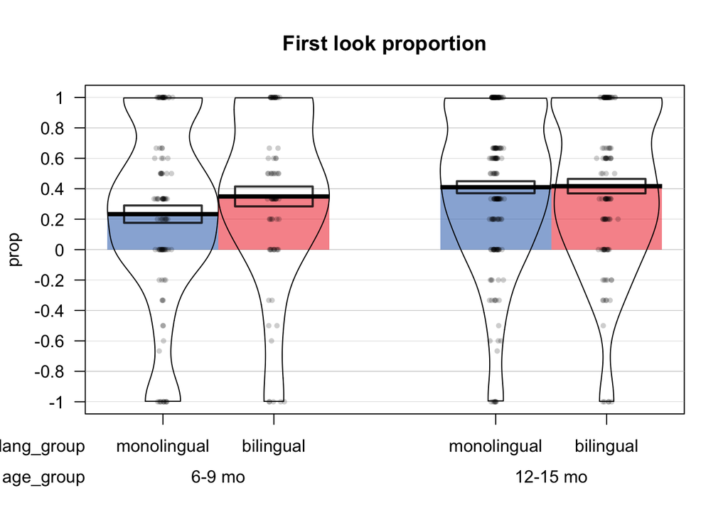

```r
d_first_meta %>%
  group_by(subid, age_group, lang_group) %>%
  summarise(prop = mean(prop, na.rm = TRUE)) %>%
  pirateplot(formula = prop ~ lang_group + age_group, data = ., main = "First look proportion", theme = 1, bar.f.o = .5, bean.f.o = 0, bar.b.col = 1, bar.lwd = .5, bean.b.col = 1, inf.f.o = 0, inf.method = "se")
```

## 3.2 Frequency

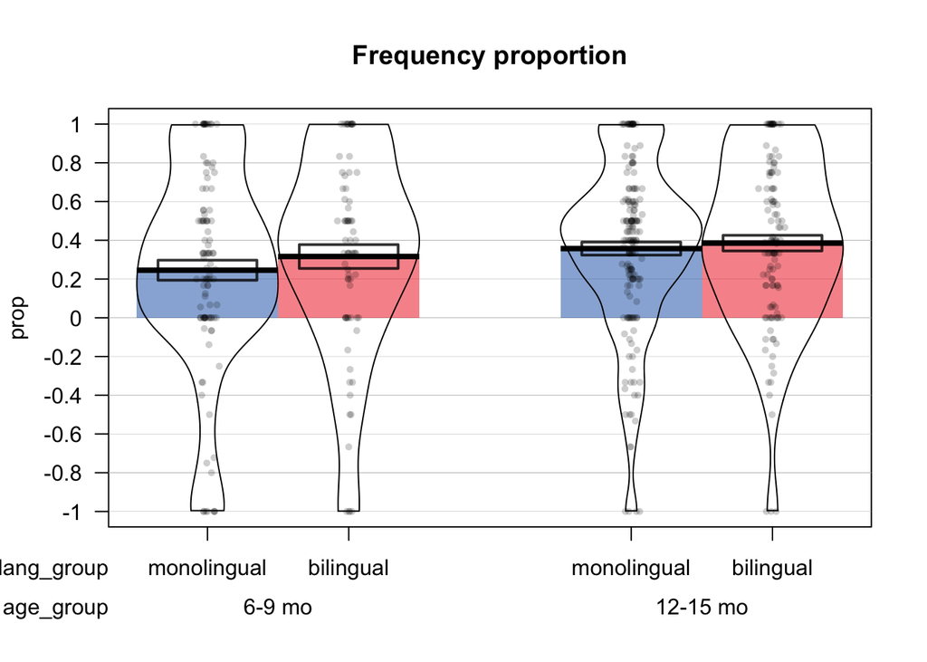

```r
pirateplot(formula = prop ~ lang_group + age_group, data = d_freq_meta, main = "Frequency proportion", theme = 1, bar.f.o = .5, bean.f.o = 0, bar.b.col = 1, bar.lwd = .5, bean.b.col = 1, inf.f.o = 0, inf.method = "se")
```

## 3.3 Duration

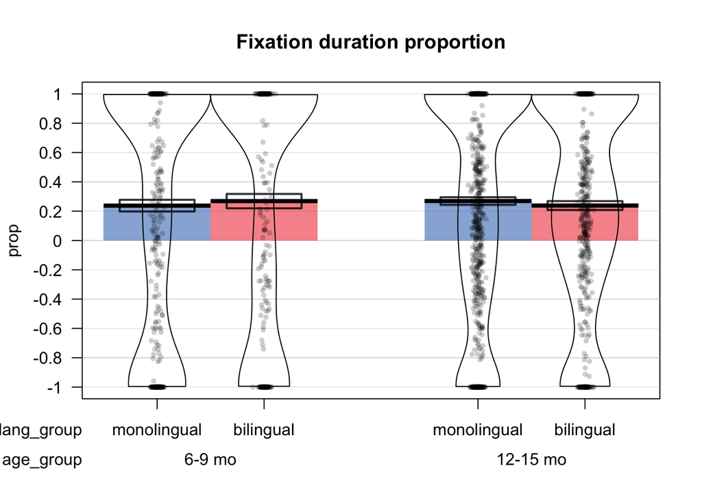

```r
pirateplot(formula = prop ~ lang_group + age_group, data = d_duration_meta, main = "Fixation duration proportion", theme = 1, bar.f.o = .5, bean.f.o = 0, bar.b.col = 1, bar.lwd = .5, bean.b.col = 1, inf.f.o = 0, inf.method = "se")
```

## 3.4 Latency

```
## [1] "theme must be an integer between 0 and 4. I'll set it to 1 for now."
```

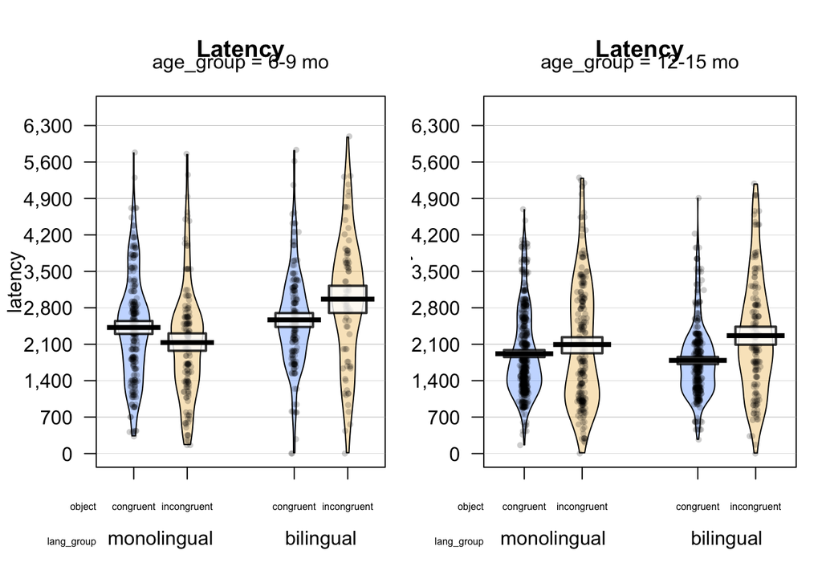

```r
pirateplot(formula = latency ~ object + lang_group + age_group, data = d_latency_meta, main = "Latency", theme = 6, pal = "southpark", cex.names = .5)
```

# 4 Meta-analytic framework

## 4.1 First-look means

```r
d_first_meta %>%
  group_by(age_group, lang_group) %>%
  summarise(sd_norm = sd(prop), prop = mean(prop), sd_prop = sqrt(prop*(1-prop))) %>% #
  select(age_group, lang_group, prop, sd_prop, sd_norm)
```

```
## # A tibble: 4 x 5
## # Groups:   age_group [2]
##   age_group lang_group   prop sd_prop sd_norm
##   <fct>     <fct>       <dbl>   <dbl>   <dbl>
## 1 6-9 mo    monolingual 0.233   0.423   0.585
## 2 6-9 mo    bilingual   0.349   0.477   0.558
## 3 12-15 mo  monolingual 0.410   0.492   0.518
## 4 12-15 mo  bilingual   0.417   0.493   0.521
```

```r
d_z_first <- d_first_meta %>%
  group_by(subid, lab, age_group, lang_group) %>%
  summarise(mean_prop = mean(prop, na.rm = TRUE)) %>%
  group_by(lab, age_group, lang_group) %>%
  summarise(d = mean(mean_prop, na.rm = TRUE) / sd(mean_prop, na.rm = TRUE),
            n = length(unique(subid)),
            d_var = d_var_calc(n, d)) %>%
 filter(n >= 10) #Filtering out subgroups with fewer than 10 babies
```

## 4.2 First look model with language and age

```r
first_meta <- metafor::rma(d ~ lang_group * age_group, vi = d_var,
                    slab = lab, data = d_z_first, method = "REML")
summary(first_meta)
```

```
##
## Mixed-Effects Model (k = 25; tau^2 estimator: REML)
##
##   logLik  deviance       AIC       BIC      AICc
## -17.3307   34.6614   44.6614   49.8840   48.6614
##
## tau^2 (estimated amount of residual heterogeneity):     0.1145 (SE = 0.0811)
## tau (square root of estimated tau^2 value):             0.3384
## I^2 (residual heterogeneity / unaccounted variability): 43.88%
## H^2 (unaccounted variability / sampling variability):   1.78
## R^2 (amount of heterogeneity accounted for):            12.47%
##
## Test for Residual Heterogeneity:
## QE(df = 21) = 38.9269, p-val = 0.0100
##
## Test of Moderators (coefficient(s) 2:4):
## QM(df = 3) = 4.6509, p-val = 0.1992
##
## Model Results:
##
##                                        estimate      se     zval    pval
## intrcpt                                  0.5129  0.2210   2.3204  0.0203
## lang_groupbilingual                      0.1713  0.3502   0.4893  0.6246
## age_group12-15 mo                        0.5762  0.2797   2.0601  0.0394
## lang_groupbilingual:age_group12-15 mo   -0.3921  0.4358  -0.8998  0.3682
##                                          ci.lb   ci.ub
## intrcpt                                 0.0797  0.9461  *
## lang_groupbilingual                    -0.5150  0.8576
## age_group12-15 mo                       0.0280  1.1245  *
## lang_groupbilingual:age_group12-15 mo  -1.2464  0.4621
##
## ---
## Signif. codes:  0 '***' 0.001 '**' 0.01 '*' 0.05 '.' 0.1 ' ' 1
```

## 4.3 Frequency means

```r
d_freq_meta %>%
  group_by(age_group, lang_group) %>%
  summarise(sd = sd(prop, na.rm = TRUE), prop = mean(prop, na.rm = TRUE)) %>%
  select(age_group, lang_group, prop, sd)
```

```
## # A tibble: 4 x 4
## # Groups:   age_group [2]
##   age_group lang_group   prop    sd
##   <fct>     <fct>       <dbl> <dbl>
## 1 6-9 mo    monolingual 0.246 0.530
## 2 6-9 mo    bilingual   0.316 0.526
## 3 12-15 mo  monolingual 0.357 0.442
## 4 12-15 mo  bilingual   0.385 0.441
```

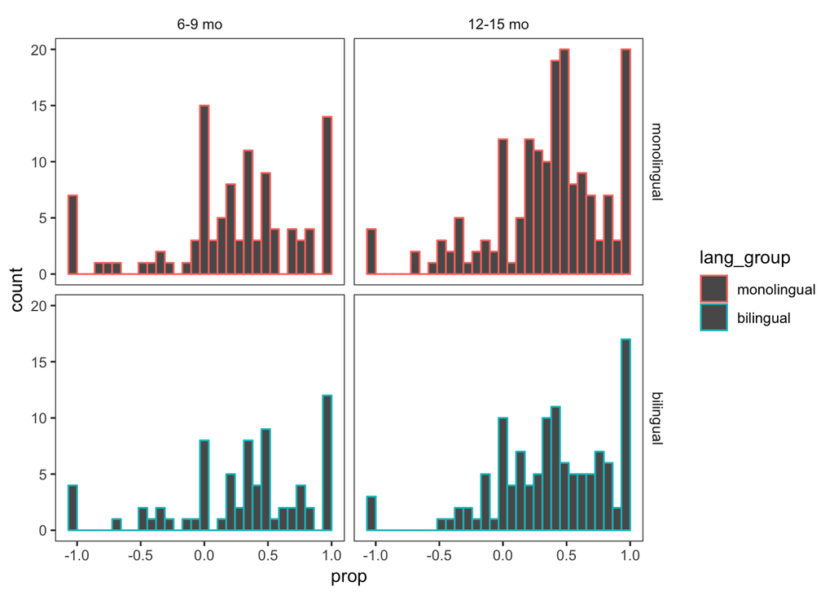

```r
d_freq_meta %>%
  ggplot(aes(x = prop, color = lang_group)) +
  facet_grid(lang_group~age_group) +
  geom_histogram()
```

```r
d_z_freq <- d_freq_meta %>%
  group_by(lab, age_group, lang_group) %>%
  summarise(d = mean(prop, na.rm = TRUE) / sd(prop, na.rm = TRUE),
            n = length(unique(subid)),
            d_var = d_var_calc(n, d)) %>%
  filter(n >= 10) #Filtering out subgroups with fewer than 10 babies
```

```r
freq_meta <- metafor::rma(d ~ lang_group * age_group, vi = d_var,
                    slab = lab, data = d_z_freq, method = "REML")
summary(freq_meta)
```

```
##
## Mixed-Effects Model (k = 25; tau^2 estimator: REML)
##
##   logLik  deviance       AIC       BIC      AICc
## -16.3330   32.6659   42.6659   47.8885   46.6659
##
## tau^2 (estimated amount of residual heterogeneity):     0.1013 (SE = 0.0768)
## tau (square root of estimated tau^2 value):             0.3183
## I^2 (residual heterogeneity / unaccounted variability): 40.90%
## H^2 (unaccounted variability / sampling variability):   1.69
## R^2 (amount of heterogeneity accounted for):            7.02%
##
## Test for Residual Heterogeneity:
## QE(df = 21) = 36.6927, p-val = 0.0183
##
## Test of Moderators (coefficient(s) 2:4):
## QM(df = 3) = 3.3734, p-val = 0.3376
##
## Model Results:
##
##                                        estimate      se     zval    pval
## intrcpt                                  0.5900  0.2160   2.7314  0.0063
## lang_groupbilingual                      0.0797  0.3433   0.2323  0.8163
## age_group12-15 mo                        0.4569  0.2723   1.6778  0.0934
## lang_groupbilingual:age_group12-15 mo   -0.2304  0.4258  -0.5411  0.5884
##                                          ci.lb   ci.ub
## intrcpt                                 0.1666  1.0133  **
## lang_groupbilingual                    -0.5931  0.7525
## age_group12-15 mo                      -0.0768  0.9906   .
## lang_groupbilingual:age_group12-15 mo  -1.0649  0.6041
##
## ---
## Signif. codes:  0 '***' 0.001 '**' 0.01 '*' 0.05 '.' 0.1 ' ' 1
```

# 5 MLM framework

## 5.1 First_look MLM

```r
first_glmer <- d_first %>%
  mutate(age_days = scale(age_days, scale = FALSE)) %>%
  filter(!is.na(first_shift)) %>%
  mutate(first_shift = fct_rev(first_shift)) %>% # So higher numbers mean more looks to congruent
  glmer(first_shift ~ lang_group*age_days + (1|subid) + (lang_group|lab) + (lang_group|trial_num),
  data = .,
  family = binomial
)


summary(first_glmer)
```

```
## Generalized linear mixed model fit by maximum likelihood (Laplace
##   Approximation) [glmerMod]
##  Family: binomial  ( logit )
## Formula:
## first_shift ~ lang_group * age_days + (1 | subid) + (lang_group |
##     lab) + (lang_group | trial_num)
##    Data: .
##
##      AIC      BIC   logLik deviance df.resid
##   2440.0   2501.5  -1209.0   2418.0     1967
##
## Scaled residuals:
##     Min      1Q  Median      3Q     Max
## -2.0641 -1.2421  0.6009  0.6620  1.3263
##
## Random effects:
##  Groups    Name                Variance Std.Dev. Corr
##  subid     (Intercept)         0.03031  0.1741
##  lab       (Intercept)         0.22353  0.4728
##            lang_groupbilingual 0.04270  0.2066   -1.00
##  trial_num (Intercept)         0.01369  0.1170
##            lang_groupbilingual 0.03378  0.1838   -1.00
## Number of obs: 1978, groups:  subid, 470; lab, 13; trial_num, 6
##
## Fixed effects:
##                                Estimate Std. Error z value Pr(>|z|)
## (Intercept)                   0.7379771  0.1568202   4.706 2.53e-06 ***
## lang_groupbilingual           0.0548453  0.1453739   0.377    0.706
## age_days                      0.0011950  0.0007977   1.498    0.134
## lang_groupbilingual:age_days -0.0008122  0.0012274  -0.662    0.508
## ---
## Signif. codes:  0 '***' 0.001 '**' 0.01 '*' 0.05 '.' 0.1 ' ' 1
##
## Correlation of Fixed Effects:
##             (Intr) lng_gr ag_dys
## lng_grpblng -0.692
## age_days    -0.008  0.039
## lng_grpbl:_ -0.001  0.027 -0.608
## convergence code: 0
## singular fit
```

## 5.2 Frequency LMEM

```r
freq_lmer <- d_freq %>%
  mutate(age_days = scale(age_days, scale = FALSE)) %>%
  mutate(object_bin = (as.integer(fct_rev(object)) - 1)) %>% # Recode to binary: congruent = 1, incongruent = 0
  lmer(n_shift ~ lang_group*age_days*object+ (object|subid) + (lang_group*object|lab) + (lang_group*object|trial_num),
  data = .
)

summary(freq_lmer)
```

```
## Linear mixed model fit by REML. t-tests use Satterthwaite's method [
## lmerModLmerTest]
## Formula: n_shift ~ lang_group * age_days * object + (object | subid) +
##     (lang_group * object | lab) + (lang_group * object | trial_num)
##    Data: .
##
## REML criterion at convergence: 9009.2
##
## Scaled residuals:
##     Min      1Q  Median      3Q     Max
## -2.4371 -0.7250 -0.1393  0.6352  5.6489
##
## Random effects:
##  Groups    Name                                  Variance  Std.Dev. Corr
##  subid     (Intercept)                           6.431e-02 0.253588
##            objectincongruent                     1.176e-01 0.342935 -1.00
##  lab       (Intercept)                           2.298e-02 0.151603
##            lang_groupbilingual                   2.771e-03 0.052642 -0.74
##            objectincongruent                     8.780e-02 0.296312 -0.97
##            lang_groupbilingual:objectincongruent 4.183e-03 0.064674  1.00
##  trial_num (Intercept)                           1.545e-02 0.124305
##            lang_groupbilingual                   7.324e-05 0.008558 -1.00
##            objectincongruent                     1.313e-02 0.114607 -1.00
##            lang_groupbilingual:objectincongruent 1.942e-03 0.044069  1.00
##  Residual                                        5.271e-01 0.726018
##
##
##
##
##
##   0.55
##  -0.75 -0.97
##
##
##   1.00
##  -1.00 -1.00
##
## Number of obs: 3954, groups:  subid, 470; lab, 13; trial_num, 6
##
## Fixed effects:
```

[output cut: 26 more lines]

```
## lang_groupbilingual:age_days:objectincongruent
## ---
## Signif. codes:  0 '***' 0.001 '**' 0.01 '*' 0.05 '.' 0.1 ' ' 1
##
## Correlation of Fixed Effects:
##             (Intr) lng_gr ag_dys objctn lng_:_ lng_g: ag_dy:
## lng_grpblng -0.426
## age_days    -0.008  0.023
## objctncngrn -0.902  0.357  0.008
## lng_grpbl:_  0.003  0.008 -0.613 -0.003
## lng_grpbln:  0.539 -0.793 -0.026 -0.555 -0.006
## ag_dys:bjct  0.008 -0.027 -0.816 -0.013  0.488  0.040
## lng_grpb:_: -0.003 -0.006  0.496  0.005 -0.811  0.001 -0.601
## convergence code: 0
## singular fit
```

## 5.3 Freq_look visualization

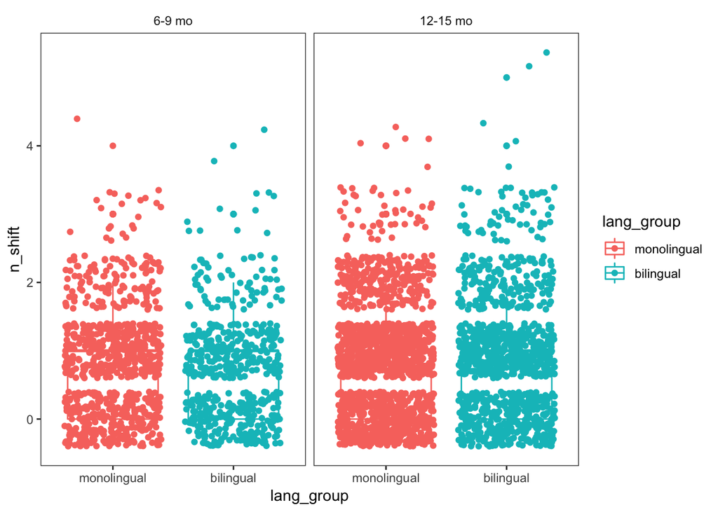

```r
d_freq %>%
  group_by(age_group, lang_group) %>%
 # summarize(prop = mean(prop, na.rm = TRUE), sd = sd(prop, na.rm = TRUE)) %>%
  ggplot(aes(x = lang_group, y = n_shift, color = lang_group)) +
  geom_boxplot() +
  geom_jitter() +
  facet_grid(.~age_group)
```

# 6 Duration LMEM

```r
duration_lmer <- d_duration %>%
  mutate(age_days = scale(age_days, scale = FALSE)) %>%
  mutate(object_bin = (as.integer(fct_rev(object)) - 1)) %>% # Recode to binary: congruent = 1, incongruent = 0
  lmer(duration ~ lang_group*age_days*object+ (object|subid) + (lang_group*object|lab) + (lang_group*object|trial_num),
  data = .
)

summary(duration_lmer)
```

```
## Linear mixed model fit by REML. t-tests use Satterthwaite's method [
## lmerModLmerTest]
## Formula: duration ~ lang_group * age_days * object + (object | subid) +
##     (lang_group * object | lab) + (lang_group * object | trial_num)
##    Data: .
##
## REML criterion at convergence: 21466.1
##
## Scaled residuals:
##     Min      1Q  Median      3Q     Max
## -2.2376 -1.0375  0.3861  0.7090  2.0814
##
## Random effects:
##  Groups    Name                                  Variance Std.Dev. Corr
##  subid     (Intercept)                           0.188411 0.43406
##            objectincongruent                     1.555241 1.24709  -1.00
##  lab       (Intercept)                           0.101785 0.31904
##            lang_groupbilingual                   0.053362 0.23100  -0.39
##            objectincongruent                     0.635736 0.79733  -0.64
##            lang_groupbilingual:objectincongruent 0.543767 0.73741   0.16
##  trial_num (Intercept)                           0.036276 0.19046
##            lang_groupbilingual                   0.002388 0.04887   0.56
##            objectincongruent                     0.090264 0.30044  -0.76
##            lang_groupbilingual:objectincongruent 0.016118 0.12696  -0.48
##  Residual                                        8.594577 2.93165
##
##
##
##
##
##  -0.38
##   0.70 -0.86
##
##
##   0.11
##   0.45  0.93
##
## Number of obs: 4250, groups:  subid, 485; lab, 13; trial_num, 6
##
## Fixed effects:
```

[output cut: 26 more lines]

```
## lang_groupbilingual:age_days:objectincongruent
## ---
## Signif. codes:  0 '***' 0.001 '**' 0.01 '*' 0.05 '.' 0.1 ' ' 1
##
## Correlation of Fixed Effects:
##             (Intr) lng_gr ag_dys objctn lng_:_ lng_g: ag_dy:
## lng_grpblng -0.395
## age_days    -0.020  0.027
## objctncngrn -0.681  0.083  0.011
## lng_grpbl:_  0.009 -0.004 -0.602 -0.004
## lng_grpbln:  0.217 -0.265 -0.020 -0.593  0.001
## ag_dys:bjct  0.013 -0.024 -0.725 -0.017  0.422  0.021
## lng_grpb:_: -0.004  0.001  0.430  0.009 -0.708  0.002 -0.616
## convergence code: 0
## singular fit
```

## 6.1 Visualize duration

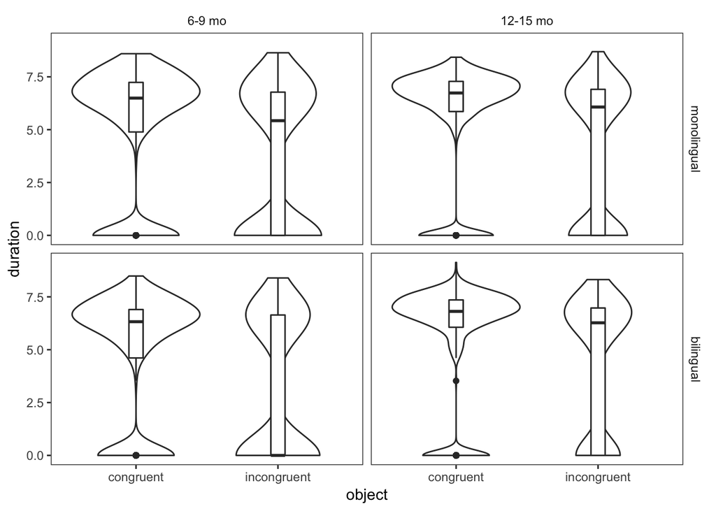

```r
d_duration %>%
 # group_by(age_group, lang_group, object) %>%
 # summarize(duration = mean(duration)) %>%
  ggplot(aes(y = duration, x = object, color - lang_group)) +
  facet_grid(lang_group ~ age_group) +
  geom_violin() +
  geom_boxplot(width = .1)
```

## 6.2 Latency LMEM

```r
latency_lmer <- d_latency %>%
  mutate(age_days = scale(age_days, scale = FALSE)) %>%
  mutate(object_bin = (as.integer(fct_rev(object)) - 1)) %>% # Recode to binary: congruent = 1, incongruent = 0
  lmer(latency ~ lang_group*age_days*object+ (object|subid) + (lang_group*object|lab) + (lang_group*object|trial_num),
  data = .
)

summary(latency_lmer)
```

```
## Linear mixed model fit by REML. t-tests use Satterthwaite's method [
## lmerModLmerTest]
## Formula: latency ~ lang_group * age_days * object + (object | subid) +
##     (lang_group * object | lab) + (lang_group * object | trial_num)
##    Data: .
##
## REML criterion at convergence: 6355.5
##
## Scaled residuals:
##     Min      1Q  Median      3Q     Max
## -6.1554 -0.2370  0.0993  0.4891  2.7615
##
## Random effects:
##  Groups    Name                                  Variance Std.Dev. Corr
##  subid     (Intercept)                           0.109199 0.33045
##            objectincongruent                     0.052918 0.23004  1.00
##  lab       (Intercept)                           0.046291 0.21515
##            lang_groupbilingual                   0.006166 0.07852  -1.00
##            objectincongruent                     0.011342 0.10650   1.00
##            lang_groupbilingual:objectincongruent 0.012905 0.11360   1.00
##  trial_num (Intercept)                           0.008890 0.09429
##            lang_groupbilingual                   0.006724 0.08200  -1.00
##            objectincongruent                     0.026707 0.16342  -0.75
##            lang_groupbilingual:objectincongruent 0.117475 0.34275   0.09
##  Residual                                        1.253517 1.11961
##
##
##
##
##
##  -1.00
##  -1.00  1.00
##
##
##   0.75
##  -0.09 -0.59
##
## Number of obs: 1978, groups:  subid, 470; lab, 13; trial_num, 6
##
## Fixed effects:
```

[output cut: 26 more lines]

```
## lang_groupbilingual:age_days:objectincongruent
## ---
## Signif. codes:  0 '***' 0.001 '**' 0.01 '*' 0.05 '.' 0.1 ' ' 1
##
## Correlation of Fixed Effects:
##             (Intr) lng_gr ag_dys objctn lng_:_ lng_g: ag_dy:
## lng_grpblng -0.677
## age_days    -0.029  0.038
## objctncngrn -0.178  0.283  0.008
## lng_grpbl:_  0.016 -0.017 -0.617 -0.009
## lng_grpbln:  0.249 -0.292 -0.001 -0.528  0.006
## ag_dys:bjct  0.010 -0.007 -0.370  0.041  0.239 -0.021
## lng_grpb:_: -0.004  0.010  0.234 -0.027 -0.371  0.031 -0.595
## convergence code: 0
## singular fit
```